# ML ASS 2 CVD PREDICTION MODEL2

KIBIDI

2026-04-16

## R Markdown

Course: PROFFESIONAL CERTIFICATE IN DATA ANALYSIS, MACHINE LEARNING AND AI Instructor: Lumumba W. Victor Email: lumumbavictor172@gmail.com

student: KIBIDI LERENCER Reg no: CDAM/0047/2026 Email: kabeyi24leren@gmail.com

Date Issued: April , 2026

```r
setwd("C:/Users/h6p/Desktop/ASSIGNMENTS")
```

3 Tasks 3.1 Task 1: Data Import and Exploration (10 Marks)

#3.1.1. Load all necessary libraries

```r
library(tidyverse)# Data manipulation
library(caret)# Unified ML interface
library(pROC)# ROC analysis
library(e1071)# SVM
library(class)# KNN
library(randomForest) # Random Forest
library(dplyr)
library(vip)
```

#3.1.2. Import the dataset medical_data.csv.

```r
hypertension <- read_csv("medical_data.csv")
head(hypertension)
```

```
## # A tibble: 6 × 16
##     age gender   bmi blood_pressure cholesterol glucose smoking alcohol
##   <dbl>  <dbl> <dbl>          <dbl>       <dbl>   <dbl>   <dbl>   <dbl>
## 1  36.6      0  19.9           127.        207.   106.        1       0
## 2  41.5      1  32.1           126.        144.    76.9       1       1
## 3  68.4      1  30.4           105.        156.   102.        1       0
## 4  46.1      1  25.5           140.        257.   131.        0       0
## 5  46.9      0  26.9           108.        139.    58.7       0       0
## 6  70.7      0  29.4           135.        285.    78.2       0       0
## # ℹ 8 more variables: physical_activity <dbl>, family_history <dbl>,
## #   stress_level <dbl>, heart_rate <dbl>, sleep_hours <dbl>,
## #   medication_adherence <dbl>, urban_residence <dbl>, CVD <chr>
```

#3.1.3a) Display the structure of the data (str())

```r
(str(hypertension))
```

```
## spc_tbl_ [2,500 × 16] (S3: spec_tbl_df/tbl_df/tbl/data.frame)
##  $ age                 : num [1:2500] 36.6 41.5 68.4 46.1 46.9 ...
##  $ gender              : num [1:2500] 0 1 1 1 0 0 0 1 1 0 ...
##  $ bmi                 : num [1:2500] 19.9 32.1 30.4 25.5 26.9 ...
##  $ blood_pressure      : num [1:2500] 127 126 105 140 108 ...
##  $ cholesterol         : num [1:2500] 207 144 156 257 139 ...
##  $ glucose             : num [1:2500] 105.8 76.9 101.6 130.7 58.7 ...
##  $ smoking             : num [1:2500] 1 1 1 0 0 0 0 0 0 0 ...
##  $ alcohol             : num [1:2500] 0 1 0 0 0 0 1 0 1 0 ...
##  $ physical_activity   : num [1:2500] 1.66 1.55 3.9 3.49 1.58 ...
##  $ family_history      : num [1:2500] 0 0 0 1 0 0 1 1 0 0 ...
##  $ stress_level        : num [1:2500] 3.327 4.559 0.793 1.664 2.804 ...
##  $ heart_rate          : num [1:2500] 77.8 79.9 77.9 83.5 90.3 ...
##  $ sleep_hours         : num [1:2500] 5.81 5.3 7.87 7.78 7.31 ...
##  $ medication_adherence: num [1:2500] 1 0 1 1 0 1 0 1 1 1 ...
##  $ urban_residence     : num [1:2500] 1 1 1 0 0 1 0 1 1 1 ...
##  $ CVD                 : chr [1:2500] "No" "No" "No" "No" ...
##  - attr(*, "spec")=
##   .. cols(
##   ..   age = col_double(),
##   ..   gender = col_double(),
##   ..   bmi = col_double(),
##   ..   blood_pressure = col_double(),
##   ..   cholesterol = col_double(),
##   ..   glucose = col_double(),
##   ..   smoking = col_double(),
##   ..   alcohol = col_double(),
##   ..   physical_activity = col_double(),
##   ..   family_history = col_double(),
##   ..   stress_level = col_double(),
##   ..   heart_rate = col_double(),
##   ..   sleep_hours = col_double(),
##   ..   medication_adherence = col_double(),
##   ..   urban_residence = col_double(),
##   ..   CVD = col_character()
##   .. )
##  - attr(*, "problems")=<externalptr>
```

#3.1.3b) Display summary statistics (summary()).

```r
(summary(hypertension))
```

```
##       age              gender            bmi        blood_pressure
##  Min.   :-0.7179   Min.   :0.0000   Min.   :10.55   Min.   : 72.32
##  1st Qu.:35.2672   1st Qu.:0.0000   1st Qu.:23.70   1st Qu.:119.62
##  Median :44.9432   Median :0.0000   Median :27.08   Median :129.92
##  Mean   :45.1594   Mean   :0.4916   Mean   :26.99   Mean   :130.09
##  3rd Qu.:54.9905   3rd Qu.:1.0000   3rd Qu.:30.32   3rd Qu.:140.70
##  Max.   :95.8556   Max.   :1.0000   Max.   :45.58   Max.   :187.72
##   cholesterol        glucose           smoking          alcohol
##  Min.   : 63.92   Min.   :  2.665   Min.   :0.0000   Min.   :0.000
##  1st Qu.:173.84   1st Qu.: 79.766   1st Qu.:0.0000   1st Qu.:0.000
##  Median :199.01   Median : 99.732   Median :0.0000   Median :0.000
##  Mean   :199.80   Mean   : 99.649   Mean   :0.2904   Mean   :0.384
##  3rd Qu.:227.21   3rd Qu.:120.783   3rd Qu.:1.0000   3rd Qu.:1.000
##  Max.   :322.70   Max.   :187.584   Max.   :1.0000   Max.   :1.000
##  physical_activity family_history    stress_level      heart_rate
##  Min.   :-2.127    Min.   :0.0000   Min.   :-1.560   Min.   : 39.54
##  1st Qu.: 1.925    1st Qu.:0.0000   1st Qu.: 3.642   1st Qu.: 67.82
##  Median : 2.909    Median :0.0000   Median : 4.994   Median : 74.95
##  Mean   : 2.930    Mean   :0.2472   Mean   : 4.970   Mean   : 74.96
##  3rd Qu.: 3.905    3rd Qu.:0.0000   3rd Qu.: 6.297   3rd Qu.: 82.19
##  Max.   : 8.555    Max.   :1.0000   Max.   :12.843   Max.   :118.23
##   sleep_hours     medication_adherence urban_residence     CVD
##  Min.   : 2.544   Min.   :0.0000       Min.   :0.000   Length:2500
##  1st Qu.: 5.938   1st Qu.:0.0000       1st Qu.:0.000   Class :character
##  Median : 6.919   Median :1.0000       Median :1.000   Mode  :character
##  Mean   : 6.953   Mean   :0.6792       Mean   :0.596
##  3rd Qu.: 7.985   3rd Qu.:1.0000       3rd Qu.:1.000
##  Max.   :12.253   Max.   :1.0000       Max.   :1.000
```

#3.1.4a) Check for missing values per variable.

```r
colSums(is.na(hypertension))
```

```
##                  age               gender                  bmi
##                    0                    0                    0
##       blood_pressure          cholesterol              glucose
##                    0                    0                    0
##              smoking              alcohol    physical_activity
##                    0                    0                    0
##       family_history         stress_level           heart_rate
##                    0                    0                    0
##          sleep_hours medication_adherence      urban_residence
##                    0                    0                    0
##                  CVD
##                    0
```

#3.1.4b) report the count and percentage per variable.

```r
missing_summary <- data.frame(
  Variable = names(hypertension),
  Missing_Count = colSums(is.na(hypertension)),
  Missing_Percent = colMeans(is.na(hypertension)) * 100
)

missing_summary
```

```
##                                  Variable Missing_Count Missing_Percent
## age                                   age             0               0
## gender                             gender             0               0
## bmi                                   bmi             0               0
## blood_pressure             blood_pressure             0               0
## cholesterol                   cholesterol             0               0
## glucose                           glucose             0               0
## smoking                           smoking             0               0
## alcohol                           alcohol             0               0
## physical_activity       physical_activity             0               0
## family_history             family_history             0               0
## stress_level                 stress_level             0               0
## heart_rate                     heart_rate             0               0
## sleep_hours                   sleep_hours             0               0
## medication_adherence medication_adherence             0               0
## urban_residence           urban_residence             0               0
## CVD                                   CVD             0               0
```

#3.1.5. Visualize the distribution of the target variable CVD using a bar plot.

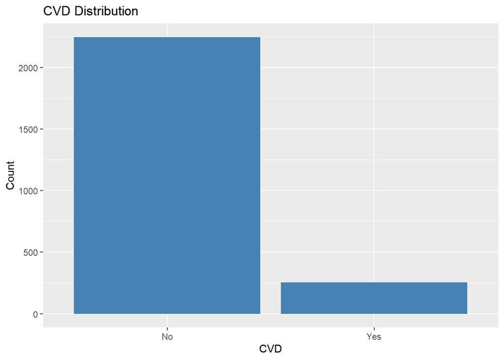

```r
 ggplot(hypertension, aes(x = factor(CVD))) +
geom_bar(fill = "steelblue") +
labs(title = "CVD Distribution", x = "CVD", y = "Count")
```

#3.1.6a) Calculate and report the class imbalance ratio

```r
class_counts <- table(hypertension$CVD)

IR <- max(class_counts) / min(class_counts)

IR
```

```
## [1] 8.881423
```

```r
#percentage
prop.table(class_counts) * 100
```

```
##
##    No   Yes
## 89.88 10.12
```

#3.1.6b)visualize class imbalance ratio in percentage

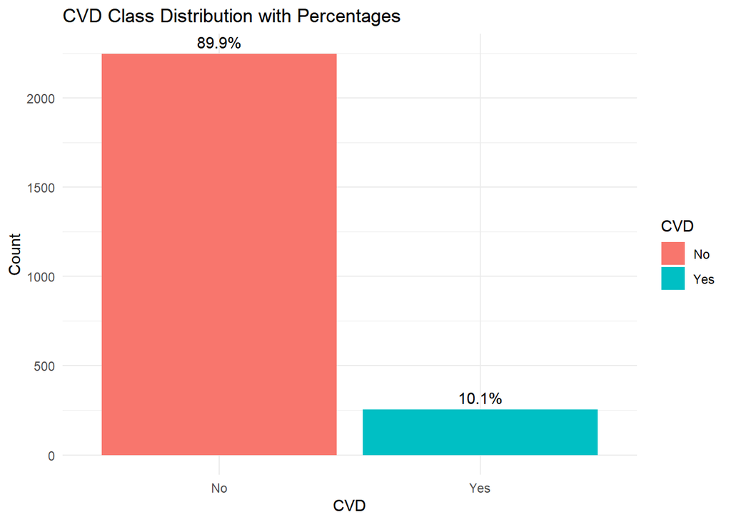

```r
hypertension %>%
  count(CVD) %>%
  mutate(Percent = n / sum(n) * 100) %>%
  ggplot(aes(x = CVD, y = n, fill = CVD)) +
  geom_bar(stat = "identity") +
  geom_text(aes(label = paste0(round(Percent,1), "%")),
            vjust = -0.5) +
  labs(title = "CVD Class Distribution with Percentages",
       x = "CVD",
       y = "Count") +
  theme_minimal()
```

#3.1.3c)Frequency of variables m

```r
table(hypertension$gender)
```

```
##
##    0    1
## 1271 1229
```

```r
table(hypertension$smoking)
```

```
##
##    0    1
## 1774  726
```

```r
table(hypertension$alcohol)
```

```
##
##    0    1
## 1540  960
```

```r
table(hypertension$family_history)
```

```
##
##    0    1
## 1882  618
```

```r
table(hypertension$medication_adherence)
```

```
##
##    0    1
##  802 1698
```

```r
table(hypertension$urban_residence)
```

```
##
##    0    1
## 1010 1490
```

```r
table(hypertension$CVD)
```

```
##
##   No  Yes
## 2247  253
```

3.2 Task 2: Data Preprocessing (15 Marks) #3.2.1. Handle missing values (justify your method: removal or imputation).

```r
hypertension_clean <- na.omit(hypertension)
```

Missing values were handled using removal because the dataset contained no significant missing data,this is to ensure data completeness without introducing bias from imputation.

#3.2.2. Convert categorical variables to factors:

```r
categorical_vars <- c("gender", "smoking", "alcohol",
                      "family_history", "medication_adherence", "urban_residence")

hypertension_clean[categorical_vars] <- lapply(hypertension_clean[categorical_vars], as.factor)
```

#3.2.3a) Convert the target variable CVD to a factor with levels “No” (0) and “Yes” (1).

```r
hypertension_clean$CVD <- factor(hypertension_clean$CVD,
                                 levels = c("No", "Yes"))
```

#3.2.5b.outlier visualization

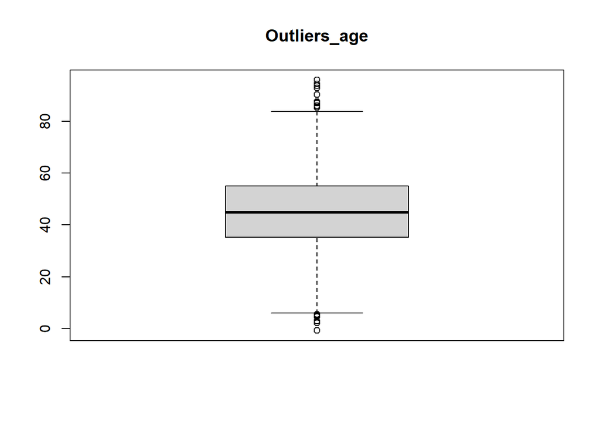

```r
boxplot(hypertension_clean$age, main="Outliers_age")
```

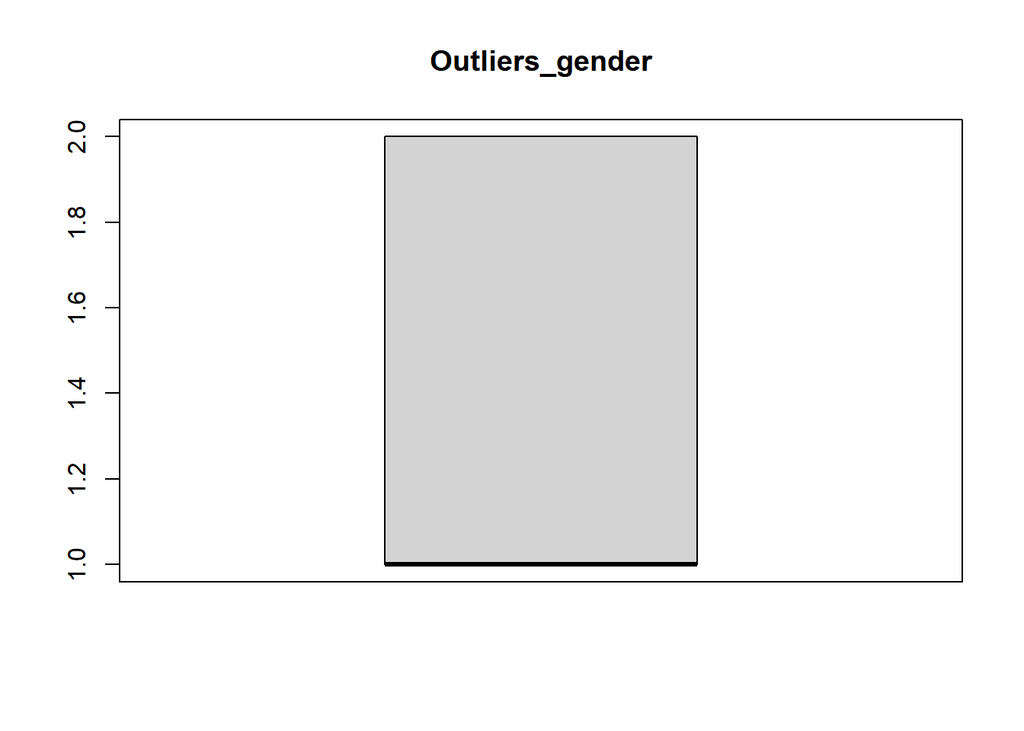

```r
boxplot(hypertension_clean$gender, main="Outliers_gender")
```

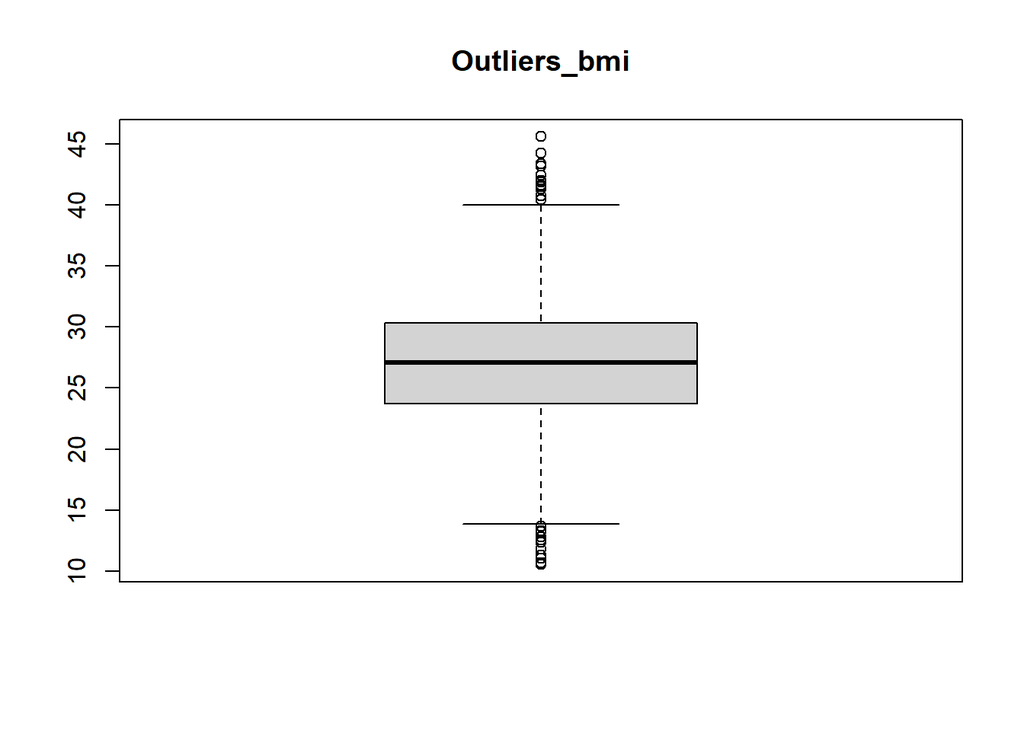

```r
boxplot(hypertension_clean$bmi, main="Outliers_bmi")
```

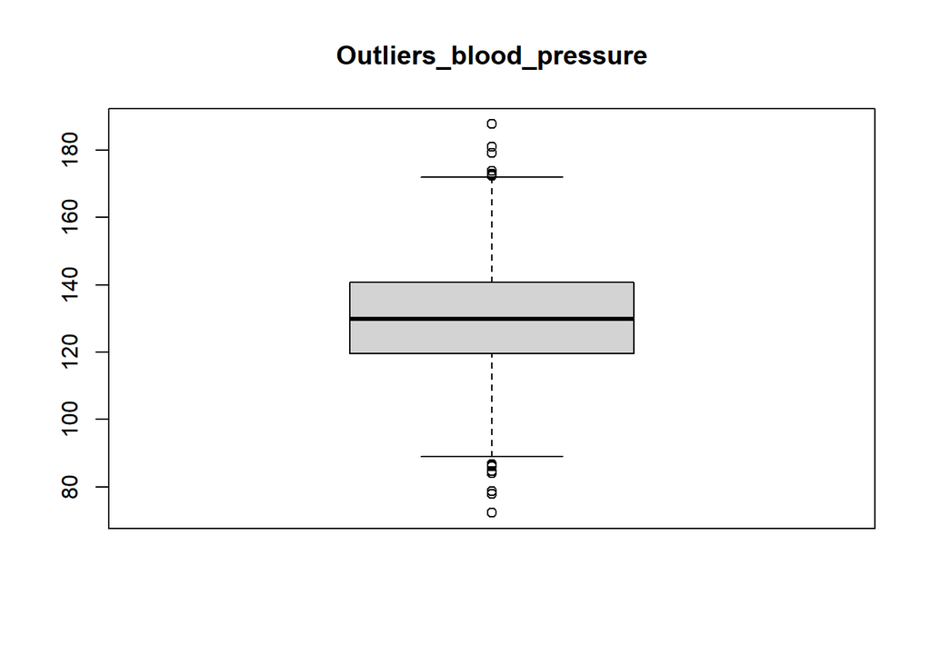

```r
boxplot(hypertension_clean$blood_pressure, main="Outliers_blood_pressure")
```

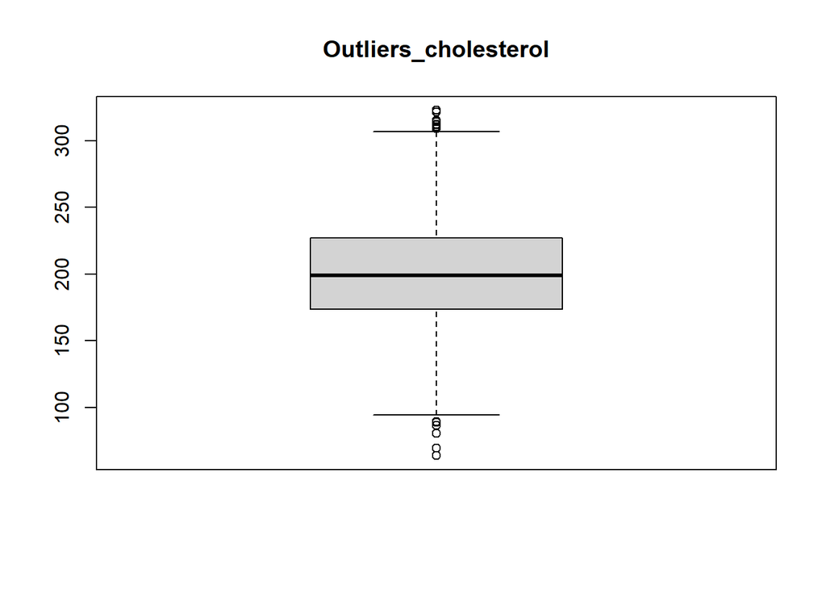

```r
boxplot(hypertension_clean$cholesterol, main="Outliers_cholesterol")
```

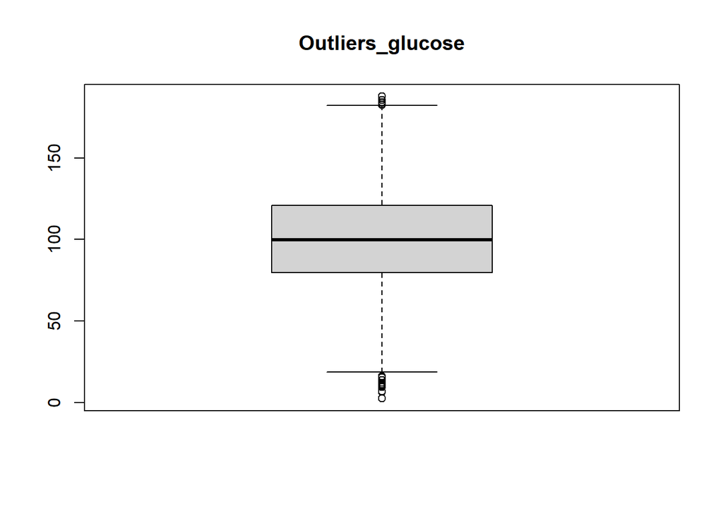

```r
boxplot(hypertension_clean$glucose, main="Outliers_glucose")
```

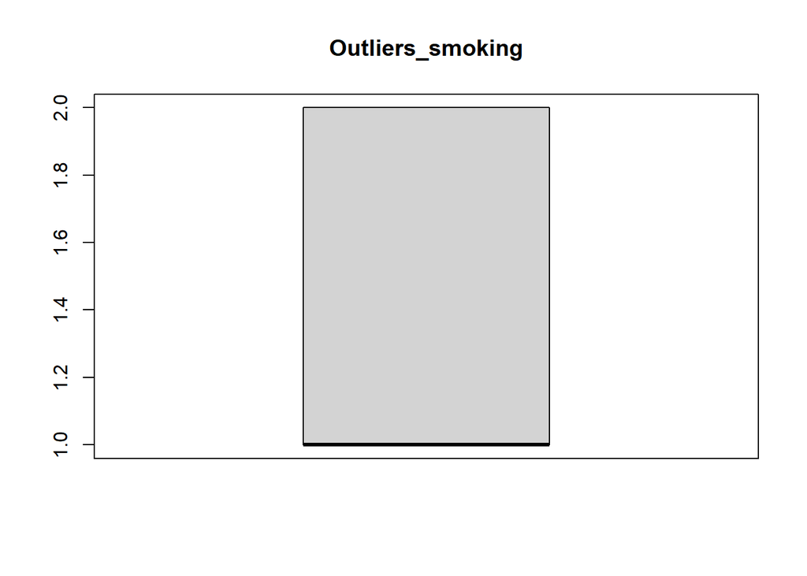

```r
boxplot(hypertension_clean$smoking, main="Outliers_smoking")
```

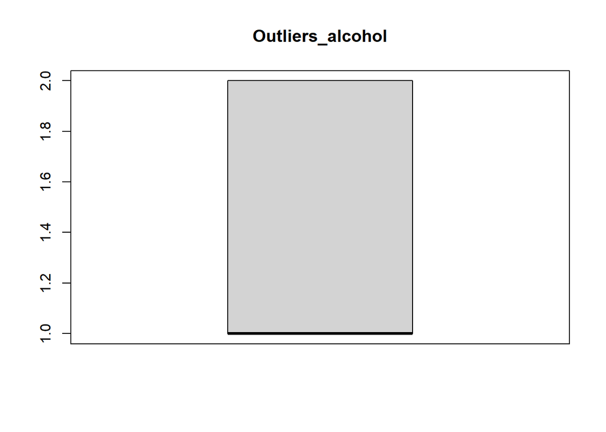

```r
boxplot(hypertension_clean$alcohol, main="Outliers_alcohol")
```

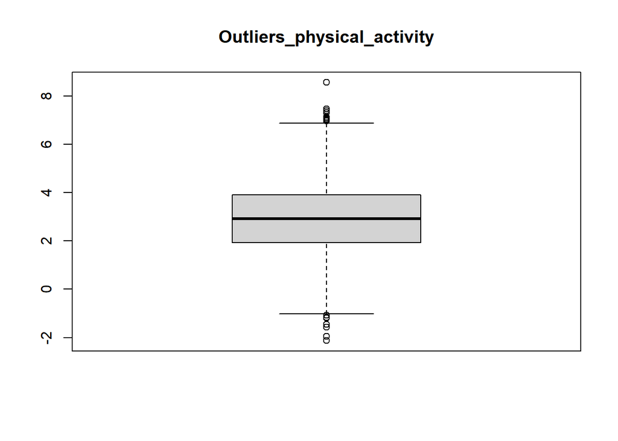

```r
boxplot(hypertension_clean$physical_activity, main="Outliers_physical_activity")
```

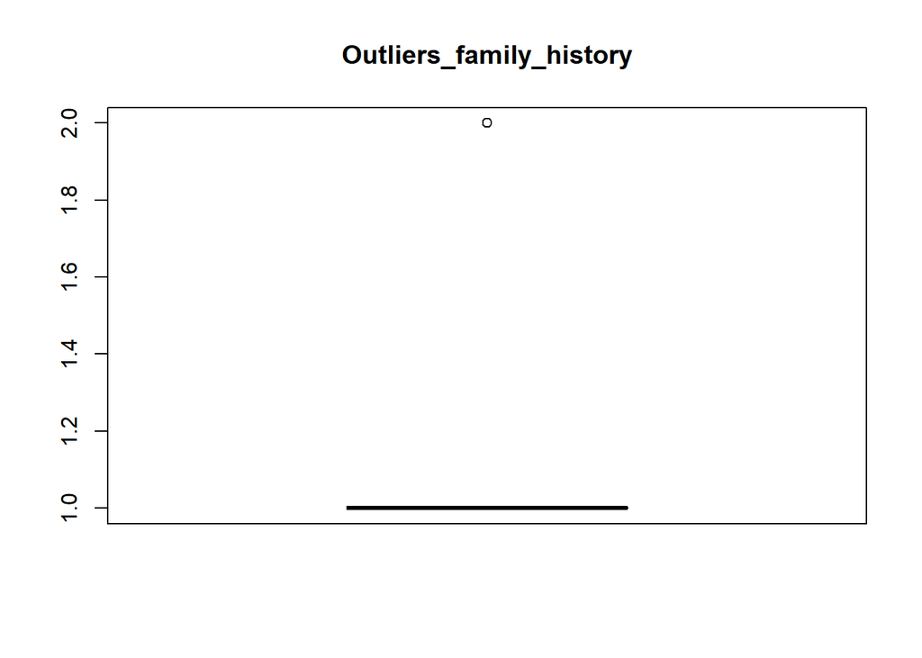

```r
boxplot(hypertension_clean$family_history, main="Outliers_family_history")
```

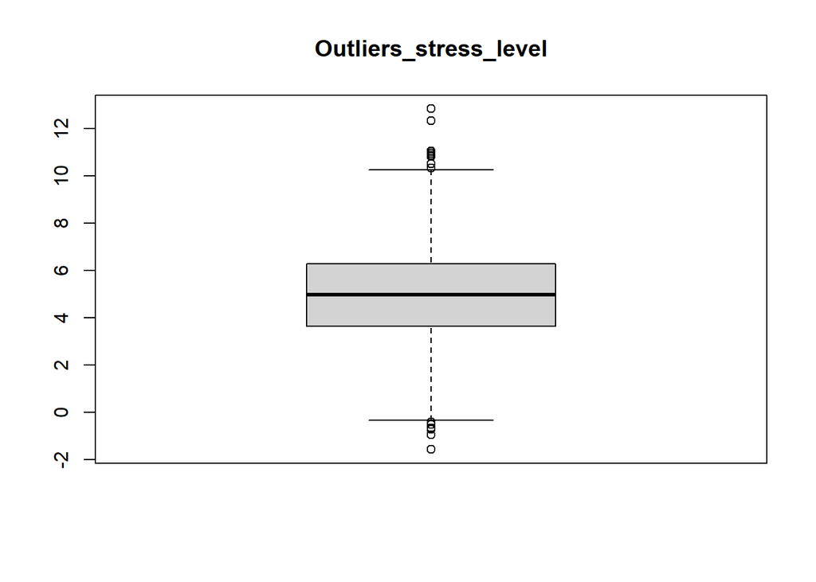

```r
boxplot(hypertension_clean$stress_level, main="Outliers_stress_level")
```

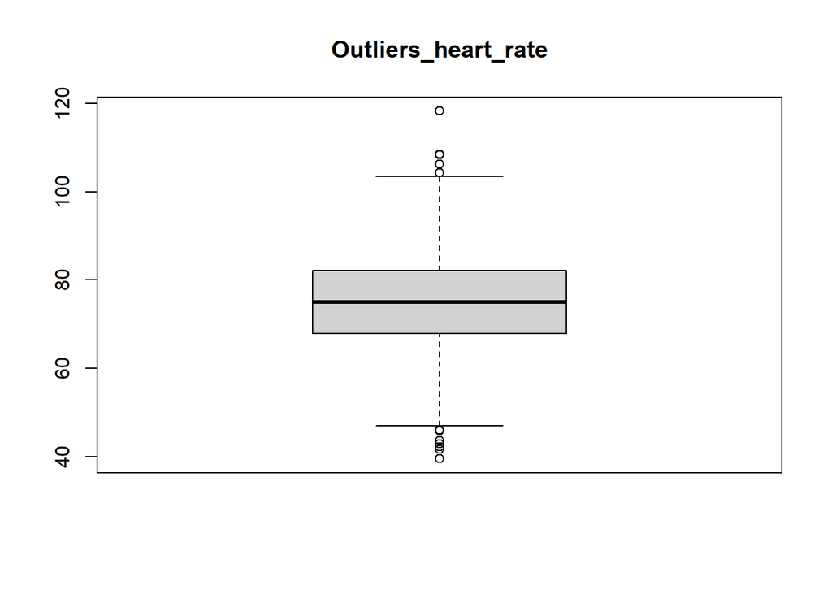

```r
boxplot(hypertension_clean$heart_rate, main="Outliers_heart_rate")
```

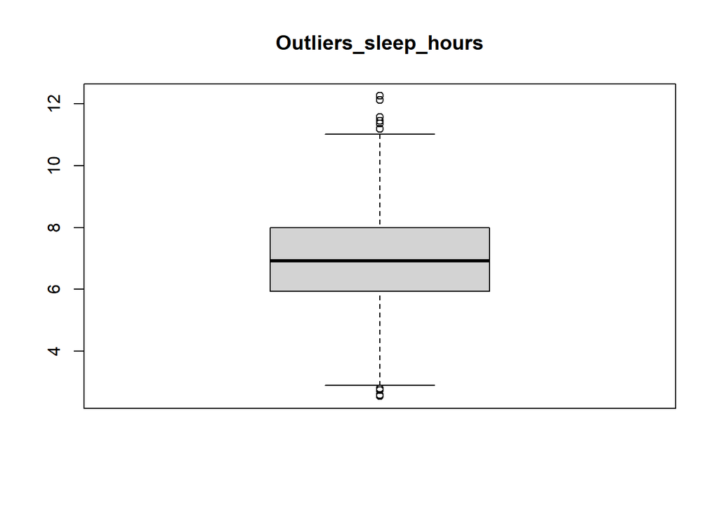

```r
boxplot(hypertension_clean$sleep_hours, main="Outliers_sleep_hours")
```

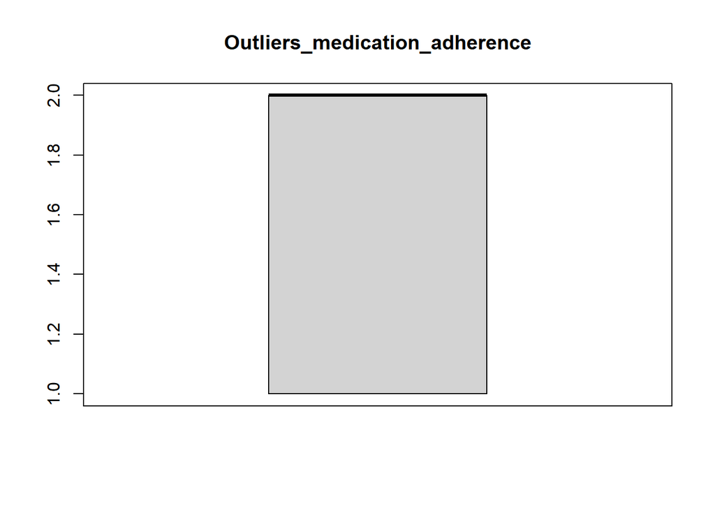

```r
boxplot(hypertension_clean$medication_adherence, main="Outliers_medication_adherence")
```

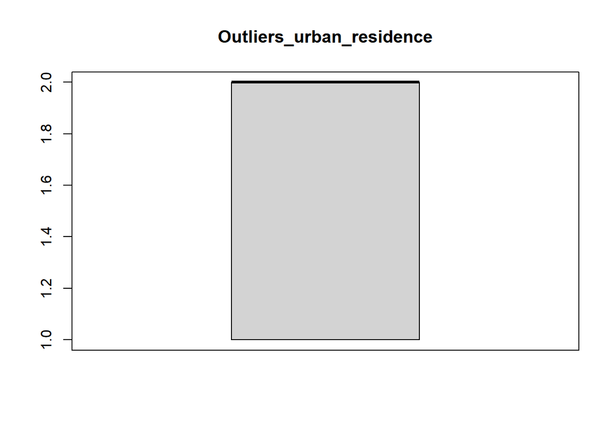

```r
boxplot(hypertension_clean$urban_residence, main="Outliers_urban_residence")
```

# Function to remove outliers using IQR from a single column

```r
remove_outliers_iqr <- function(x) {
  Q1 <- quantile(x, 0.25, na.rm = TRUE)
  Q3 <- quantile(x, 0.75, na.rm = TRUE)
  IQR <- Q3 - Q1
  lower_bound <- Q1 - 1.5 * IQR
  upper_bound <- Q3 + 1.5 * IQR
  return(x >= lower_bound & x <= upper_bound)  # Returns TRUE for non-outliers
}

# Apply to all numeric columns in your dataset
numeric_cols <- names(hypertension_clean)[sapply(hypertension_clean, is.numeric)]

# Create logical vector for rows to KEEP (no outliers in ANY column)
keep_rows <- rep(TRUE, nrow(hypertension_clean))

for(col in numeric_cols) {
  keep_rows <- keep_rows & remove_outliers_iqr(hypertension_clean[[col]])
}

# Remove rows with outliers
hypertension_cleant <- hypertension_clean[keep_rows, ]

cat("Original rows:", nrow(hypertension_clean))
```

```
## Original rows: 2500
```

```r
cat("Rows after outlier removal:", nrow(hypertension_cleant))
```

```
## Rows after outlier removal: 2355
```

```r
cat("Rows removed:", nrow(hypertension_clean) - nrow(hypertension_cleant))
```

```
## Rows removed: 145
```

N/B : hypertension_cleant DOES NOT HAVE OUTLIERS

#3.2.3b)verify factors conversion

```r
str(hypertension_cleant)
```

```
## tibble [2,355 × 16] (S3: tbl_df/tbl/data.frame)
##  $ age                 : num [1:2355] 36.6 41.5 68.4 46.1 46.9 ...
##  $ gender              : Factor w/ 2 levels "0","1": 1 2 2 2 1 1 2 2 1 1 ...
##  $ bmi                 : num [1:2355] 19.9 32.1 30.4 25.5 26.9 ...
##  $ blood_pressure      : num [1:2355] 127 126 105 140 108 ...
##  $ cholesterol         : num [1:2355] 207 144 156 257 139 ...
##  $ glucose             : num [1:2355] 105.8 76.9 101.6 130.7 58.7 ...
##  $ smoking             : Factor w/ 2 levels "0","1": 2 2 2 1 1 1 1 1 1 1 ...
##  $ alcohol             : Factor w/ 2 levels "0","1": 1 2 1 1 1 1 1 2 1 2 ...
##  $ physical_activity   : num [1:2355] 1.66 1.55 3.9 3.49 1.58 ...
##  $ family_history      : Factor w/ 2 levels "0","1": 1 1 1 2 1 1 2 1 1 1 ...
##  $ stress_level        : num [1:2355] 3.327 4.559 0.793 1.664 2.804 ...
##  $ heart_rate          : num [1:2355] 77.8 79.9 77.9 83.5 90.3 ...
##  $ sleep_hours         : num [1:2355] 5.81 5.3 7.87 7.78 7.31 ...
##  $ medication_adherence: Factor w/ 2 levels "0","1": 2 1 2 2 1 2 2 2 2 1 ...
##  $ urban_residence     : Factor w/ 2 levels "0","1": 2 2 2 1 1 2 2 2 2 1 ...
##  $ CVD                 : Factor w/ 2 levels "No","Yes": 1 1 1 1 1 1 1 1 1 1 ...
```

#3.2.4. For KNN and SVM:Scale numeric predictors(mean=0, sd=1)using preProcess()from caret. #3.2.4a) site numerical variables

```r
numeric_vars <- names(hypertension_cleant)[sapply(hypertension_cleant, is.numeric)]

numeric_vars
```

```
## [1] "age"               "bmi"               "blood_pressure"
## [4] "cholesterol"       "glucose"           "physical_activity"
## [7] "stress_level"      "heart_rate"        "sleep_hours"
```

#3.2.4b)Scale numeric predictors

```r
 numeric_vars <- c("age", "bmi", "blood_pressure", "cholesterol",
                  "glucose", "stress_level", "heart_rate", "sleep_hours")

preproc <- preProcess(hypertension_cleant[, numeric_vars],
                      method = c("center", "scale"))

hypertension_scaled <- hypertension_cleant

hypertension_scaled[, numeric_vars] <- predict(preproc,
                                               hypertension_cleant[, numeric_vars])
```

#3.2.4c)verify scaling using numerical variable ‘age’

```r
cat("\n========== SCALING VERIFICATION ==========\n")
```

```
##
## ========== SCALING VERIFICATION ==========
```

```r
cat("Original age - Mean:", mean(hypertension_cleant$age), "| SD:", sd(hypertension_clean$age), "\n")
```

```
## Original age - Mean: 45.03592 | SD: 14.83276
```

```r
cat("Scaled age - Mean:", round(mean(hypertension_scaled$age), 2), "| SD:", round(sd(hypertension_scaled$age), 2), "\n")
```

```
## Scaled age - Mean: 0 | SD: 1
```

#3.2.5a. For Random Forest: Scaling is not required (tree-based). Scaling is not required for Random Forest because it is a tree-based algorithm that splits data using thresholds rather than distance or magnitude. Therefore, changes in scale do not affect model performance or splits.

#3.2.6. Document your preprocessing decisions in the report. handling missing values’ scalling conversion to factors removal of outliers

3.3 Task 3: Data Partitioning (10 Marks)

#3.3.1. Set the seed to 2026 for reproducibility.

```r
 set.seed(2026)
```

#3.3.2. Split the data into 70% training and 30% testing using stratified sampling (to preserve class balance).

```r
 train_index <- createDataPartition(hypertension_scaled$CVD, p = 0.70,
list = FALSE)
train_data <- hypertension_cleant[train_index, ]
test_data <- hypertension_cleant[-train_index, ]

#train for svm and knn scaled
train_scaled <- hypertension_scaled[train_index, ]
test_scaled <- hypertension_scaled[-train_index, ]


dim(train_data)
```

```
## [1] 1650   16
```

```r
dim(test_data)
```

```
## [1] 705  16
```

```r
cat("\n========================\n")
dim(train_scaled)
```

```
## [1] 1650   16
```

```r
dim(test_scaled)
```

```
## [1] 705  16
```

#3.3.3. Report the class distribution (counts and percentages) in both training and testing sets.

```r
# Training Set
cat("Training Set:\n")
```

```
## Training Set:
```

```r
train_tab <- table(train_data$CVD)
print(train_tab)
```

```
##
##   No  Yes
## 1486  164
```

```r
cat("Percentages (%):\n")
```

```
## Percentages (%):
```

```r
print(round(prop.table(train_tab) * 100, 0))  # Changed from 2 to 0
```

```
##
##  No Yes
##  90  10
```

```r
cat("\n========================\n")
# Testing Set
cat("Testing Set:\n")
```

```
## Testing Set:
```

```r
test_tab <- table(test_data$CVD)
print(test_tab)
```

```
##
##  No Yes
## 636  69
```

```r
cat("Percentages (%):\n")
```

```
## Percentages (%):
```

```r
print(round(prop.table(test_tab) * 100, 0))  # Changed from 2 to 0
```

```
##
##  No Yes
##  90  10
```

3.4 Task 4: TrainControl Scheme (10 Marks)

#3.4.1. Define a trainControl scheme with the following specifications:

```r
ctrl <- trainControl(
method = "cv",              # 10-fold cross-validation
number = 10,                # 10 folds
savePredictions = "final",  # Save predictions
classProbs = TRUE,          # Enable probability predictions
verboseIter = FALSE,        # ROC, Sens, Spec

summaryFunction = twoClassSummary, # Suppress iteration output
)
```

#3.4.2. Explain why cross-validation is important for model evaluation. Reduces overfitting by evaluating model on multiple unseen folds Provides more stable and reliable performance estimates than a single train-test split Allows hyperparameter tuning without leaking test data Maximizes use of limited training data

#3.4.3. Save this control object to use across all models. For fair comparison

3.5 Task 5: Model Training- Logistic Regression (15 Marks)

#3.5.1. Train a Logistic Regression model using caret::train() with method “glm”.

```r
log_model <- train(

CVD ~ age + gender + bmi + blood_pressure + cholesterol +
      glucose + smoking + alcohol + physical_activity +
      family_history + stress_level + sleep_hours,

data = train_data,
method = "glm",
family = binomial,
trControl = ctrl
)
```

#3.5.3. Extract and report the model coefficients.

```r
summary(log_model$finalModel)$coefficients
```

```
##                       Estimate  Std. Error   z value     Pr(>|z|)
## (Intercept)       -14.34677716 1.509714031 -9.502977 2.039747e-21
## age                 0.03862052 0.007034981  5.489782 4.024294e-08
## gender1             0.24532917 0.193834927  1.265660 2.056347e-01
## bmi                 0.10766928 0.021398824  5.031551 4.865272e-07
## blood_pressure      0.03197387 0.006916625  4.622756 3.786744e-06
## cholesterol         0.01380783 0.002582562  5.346564 8.963941e-08
## glucose             0.02658279 0.003601163  7.381724 1.562526e-13
## smoking1            0.78778524 0.205658776  3.830545 1.278596e-04
## alcohol1            0.22976114 0.196474841  1.169418 2.422354e-01
## physical_activity  -0.57030851 0.077907271 -7.320350 2.473245e-13
## family_history1     1.14139718 0.205422470  5.556340 2.754893e-08
## stress_level        0.29166205 0.050719721  5.750466 8.899756e-09
## sleep_hours        -0.53118614 0.074853963 -7.096299 1.281416e-12
```

#3.5.4a) Calculate Odds Ratios (OR) for at least 3 significant predictors: OR = eβ

```r
# Calculate coefficients and odds ratios
coefficients <- coef(log_model$finalModel)
odds_ratios <- exp(coefficients)

# Create dataframe and sort
odds_df <- data.frame(
  Variable = names(odds_ratios),
  Odds_Ratio = round(odds_ratios, 3)
)

# Sort by Odds Ratio descending (largest to smallest)
odds_df <- odds_df[order(-odds_df$Odds_Ratio), ]

print(odds_df)
```

```
##                            Variable Odds_Ratio
## family_history1     family_history1      3.131
## smoking1                   smoking1      2.199
## stress_level           stress_level      1.339
## gender1                     gender1      1.278
## alcohol1                   alcohol1      1.258
## bmi                             bmi      1.114
## age                             age      1.039
## blood_pressure       blood_pressure      1.032
## glucose                     glucose      1.027
## cholesterol             cholesterol      1.014
## sleep_hours             sleep_hours      0.588
## physical_activity physical_activity      0.565
## (Intercept)             (Intercept)      0.000
```

#3.5.4b)odds table

```r
odds_table <- data.frame(
  Variable = names(odds_ratios),
  Coefficient = round(coefficients, 4),
  Odds_Ratio = round(odds_ratios, 3)
)

odds_table <- odds_table[order(-abs(odds_table$Coefficient)), ]

odds_table
```

```
##                            Variable Coefficient Odds_Ratio
## (Intercept)             (Intercept)    -14.3468      0.000
## family_history1     family_history1      1.1414      3.131
## smoking1                   smoking1      0.7878      2.199
## physical_activity physical_activity     -0.5703      0.565
## sleep_hours             sleep_hours     -0.5312      0.588
## stress_level           stress_level      0.2917      1.339
## gender1                     gender1      0.2453      1.278
## alcohol1                   alcohol1      0.2298      1.258
## bmi                             bmi      0.1077      1.114
## age                             age      0.0386      1.039
## blood_pressure       blood_pressure      0.0320      1.032
## glucose                     glucose      0.0266      1.027
## cholesterol             cholesterol      0.0138      1.014
```

#3.5.4b)Bar plot of Odds Ratios

[figure not shown]

```r
# Remove intercept for better visualization
odds_table <- odds_table[odds_table$Variable != "(Intercept)", ]

# Sort by Coefficient absolute value
odds_table <- odds_table[order(-abs(odds_table$Coefficient)), ]


ggplot(odds_table, aes(x = reorder(Variable, Odds_Ratio), y = Odds_Ratio,
                       fill = Odds_Ratio > 1)) +
  geom_bar(stat = "identity") +
  coord_flip() +
  geom_hline(yintercept = 1, linetype = "dashed", color = "red", linewidth = 1)+
  labs(title = "Odds Ratios for CVD Predictors",
       subtitle = "Values > 1 indicate risk factors, < 1 indicate protective factors",
       x = "Predictor Variable",
       y = "Odds Ratio") +
  scale_fill_manual(values = c("TRUE" = "coral", "FALSE" = "steelblue"),
                    labels = c("Risk Factor", "Protective Factor")) +
  theme_minimal() +
  theme(legend.position = "bottom",
        plot.title = element_text(hjust = 0.5, size = 14, face = "bold"),
        axis.text.y = element_text(size = 10)) +
  geom_text(aes(label = round(Odds_Ratio, 2)), hjust = -0.2, size = 3)
```

#3.5.5. Interpret the Odds Ratios in the context of CVD risk. SLIDE

#3.5.2a) Alternatively, fit a baseline model using base R glm() function.

```r
log_modelb <- glm(
  CVD ~ age + gender + bmi + blood_pressure + cholesterol +
      glucose + smoking + alcohol + physical_activity +
      family_history + stress_level + sleep_hours,

  data = train_data,
  family = binomial
)

summary(log_modelb)
```

```
##
## Call:
## glm(formula = CVD ~ age + gender + bmi + blood_pressure + cholesterol +
##     glucose + smoking + alcohol + physical_activity + family_history +
##     stress_level + sleep_hours, family = binomial, data = train_data)
##
## Coefficients:
##                     Estimate Std. Error z value Pr(>|z|)
## (Intercept)       -14.346777   1.509714  -9.503  < 2e-16 ***
## age                 0.038621   0.007035   5.490 4.02e-08 ***
## gender1             0.245329   0.193835   1.266 0.205635
## bmi                 0.107669   0.021399   5.032 4.87e-07 ***
## blood_pressure      0.031974   0.006917   4.623 3.79e-06 ***
## cholesterol         0.013808   0.002583   5.347 8.96e-08 ***
## glucose             0.026583   0.003601   7.382 1.56e-13 ***
## smoking1            0.787785   0.205659   3.831 0.000128 ***
## alcohol1            0.229761   0.196475   1.169 0.242235
## physical_activity  -0.570309   0.077907  -7.320 2.47e-13 ***
## family_history1     1.141397   0.205422   5.556 2.75e-08 ***
## stress_level        0.291662   0.050720   5.750 8.90e-09 ***
## sleep_hours        -0.531186   0.074854  -7.096 1.28e-12 ***
## ---
## Signif. codes:  0 '***' 0.001 '**' 0.01 '*' 0.05 '.' 0.1 ' ' 1
##
## (Dispersion parameter for binomial family taken to be 1)
##
##     Null deviance: 1068.37  on 1649  degrees of freedom
## Residual deviance:  736.51  on 1637  degrees of freedom
## AIC: 762.51
##
## Number of Fisher Scoring iterations: 6
```

#3.5.2b) Calculate Odds Ratios (OR) for at least 3 significant predictors: OR = eβ

```r
# Extract coefficients
coef_vals <- coef(log_modelb)

# Convert to odds ratios
odds_ratios <- exp(coef_vals)

# Get p-values from model summary
p_values <- summary(log_modelb)$coefficients[, 4]

# Create clean table
odds_table <- data.frame(
  Variable = names(coef_vals),
  Coefficient = round(coef_vals, 4),
  Odds_Ratio = round(odds_ratios, 3),
  P_value = round(p_values, 4)
)

# Remove row names
rownames(odds_table) <- NULL

# Sort by importance
odds_table <- odds_table[order(-abs(odds_table$Coefficient)), ]

odds_table
```

```
##             Variable Coefficient Odds_Ratio P_value
## 1        (Intercept)    -14.3468      0.000  0.0000
## 11   family_history1      1.1414      3.131  0.0000
## 8           smoking1      0.7878      2.199  0.0001
## 10 physical_activity     -0.5703      0.565  0.0000
## 13       sleep_hours     -0.5312      0.588  0.0000
## 12      stress_level      0.2917      1.339  0.0000
## 3            gender1      0.2453      1.278  0.2056
## 9           alcohol1      0.2298      1.258  0.2422
## 4                bmi      0.1077      1.114  0.0000
## 2                age      0.0386      1.039  0.0000
## 5     blood_pressure      0.0320      1.032  0.0000
## 7            glucose      0.0266      1.027  0.0000
## 6        cholesterol      0.0138      1.014  0.0000
```

3.6 Task 6: Model Training- KNN (15 Marks)

#3.6.1. Train a K-Nearest Neighbors model using caret::train() with method “knn”. #3.6.2a. Tune the parameter k (number of neighbors) using the grid: k = 1, 3, 5, …,21.

```r
knn_grid <- data.frame(k = seq(1, 21, by = 2))

ctrl <- trainControl(
  method = "cv",
  number = 10,
  classProbs = TRUE,
  summaryFunction = twoClassSummary
)

knn_model <- train(
  CVD ~ age + gender + bmi + blood_pressure + cholesterol +
      glucose + smoking + alcohol + physical_activity +
      family_history + stress_level + sleep_hours,

  data = train_scaled,
  method = "knn",
  tuneGrid = knn_grid,
  trControl = ctrl,
  metric = "ROC"
)

knn_model$results
```

```
##     k       ROC      Sens       Spec      ROCSD      SensSD     SpecSD
## 1   1 0.5811268 0.9313713 0.23088235 0.04234468 0.017230050 0.08076715
## 2   3 0.7024859 0.9724061 0.14044118 0.07334404 0.008057955 0.06623998
## 3   5 0.7442492 0.9818293 0.07904412 0.06142558 0.008981603 0.07036171
## 4   7 0.7653270 0.9885589 0.06139706 0.05618521 0.007795499 0.08275553
## 5   9 0.7738476 0.9932705 0.05514706 0.05235339 0.007093644 0.06796777
## 6  11 0.7892383 0.9959641 0.04963235 0.05863651 0.005676335 0.04921072
## 7  13 0.7929041 0.9966443 0.04926471 0.05870218 0.004745683 0.06363587
## 8  15 0.7918003 0.9966443 0.01875000 0.04953034 0.007249151 0.04218428
## 9  17 0.7932266 0.9986577 0.03125000 0.05180190 0.004244668 0.05311479
## 10 19 0.8030002 0.9986577 0.01875000 0.03987453 0.004244668 0.03019037
## 11 21 0.8081906 0.9993289 0.01250000 0.03579093 0.002122334 0.03952847
```

#3.6.2a.plot KNN model

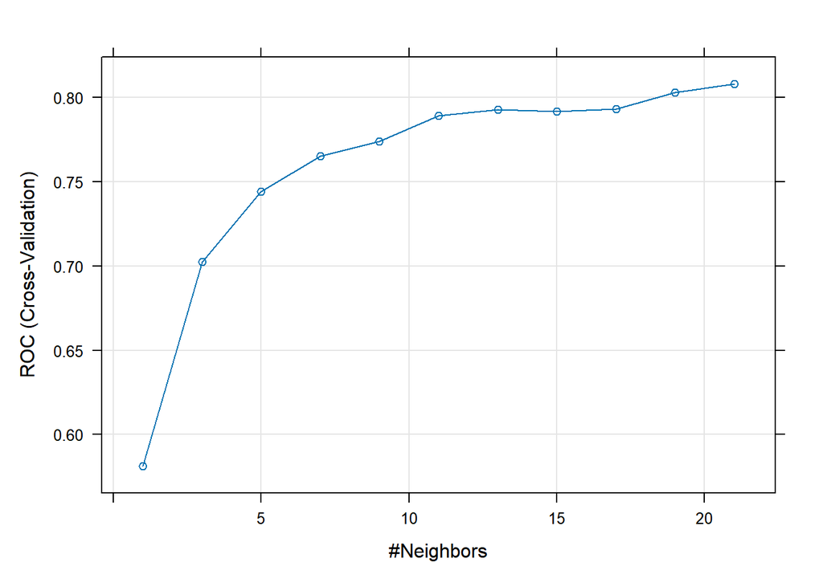

```r
plot(knn_model)
```

#3.6.3. Important: Use the scaled dataset for KNN (distance-based algorithm).

#3.6.4. Report the optimal k value selected by cross-validation.

```r
knn_model$bestTune
```

```
##     k
## 11 21
```

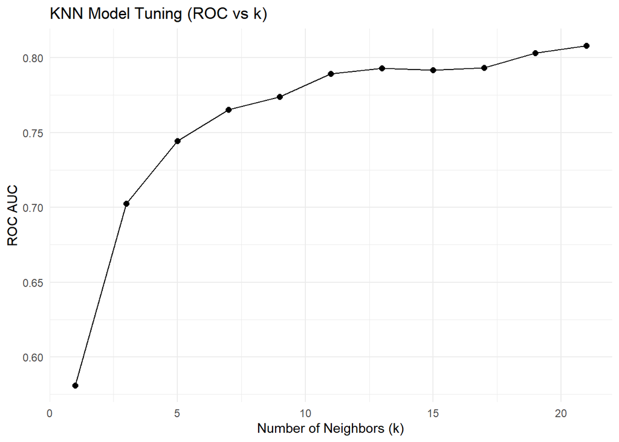

```r
ggplot(knn_model$results, aes(x = k, y = ROC)) +
  geom_line() +
  geom_point(size = 2) +
  labs(title = "KNN Model Tuning (ROC vs k)",
       x = "Number of Neighbors (k)",
       y = "ROC AUC") +
  theme_minimal()
```

3.7 Task 7: Model Training- SVM (15 Marks)

#3.7.1. Train a Support Vector Machine model using caret::train() with method “svmRadial”. #3.7.2. Tune the hyperparameters:C (cost): 0.25, 0.5, 1, 2, 4, sigma: 0.01, 0.05, 0.1, 0.5 #3.7.3. Important: Use the scaled dataset for SVM.

```r
svm_model <- train(
  CVD ~ age + gender + bmi + blood_pressure + cholesterol +
      glucose + smoking + alcohol + physical_activity +
      family_history + stress_level + sleep_hours,

data = train_scaled, # Use scaled data!
method = "svmRadial",
trControl = ctrl,
tuneGrid = expand.grid(
C = c(0.25, 0.5, 1, 2, 4),
sigma = c(0.01, 0.05, 0.1, 0.5)
))
svm_model$results
```

```
##       C sigma       ROC      Sens       Spec      ROCSD      SensSD     SpecSD
## 1  0.25  0.01 0.8253629 0.9973109 0.07352941 0.03320956 0.003471636 0.07647294
## 5  0.50  0.01 0.8254597 0.9966352 0.07389706 0.03079493 0.004752842 0.06404168
## 9  1.00  0.01 0.8248932 0.9939371 0.11544118 0.03200413 0.005902441 0.12982332
## 13 2.00  0.01 0.8249392 0.9973018 0.10330882 0.03214358 0.004720060 0.09011229
## 17 4.00  0.01 0.8251498 0.9959596 0.07316176 0.03163014 0.005678728 0.07457287
## 2  0.25  0.05 0.8229395 0.9912525 0.15183824 0.04321411 0.007131238 0.07564462
## 6  0.50  0.05 0.8229110 0.9912570 0.15147059 0.04314634 0.005530304 0.09366466
## 10 1.00  0.05 0.8228301 0.9925902 0.12757353 0.04303758 0.006711586 0.10272284
## 14 2.00  0.05 0.8236247 0.9919236 0.16360294 0.04239724 0.004252748 0.10404765
## 18 4.00  0.05 0.8237291 0.9925993 0.10992647 0.04451551 0.006682197 0.09001223
## 3  0.25  0.10 0.8144184 0.9885589 0.15772059 0.05936965 0.010526994 0.08903926
## 7  0.50  0.10 0.8145493 0.9892345 0.16397059 0.05897047 0.008499004 0.07828187
## 11 1.00  0.10 0.8145046 0.9892345 0.16397059 0.05893450 0.008499004 0.09986354
## 15 2.00  0.10 0.8159303 0.9905859 0.14007353 0.05831198 0.008490988 0.06368895
## 19 4.00  0.10 0.8104040 0.9919236 0.11507353 0.05645679 0.006183907 0.10591880
## 4  0.25  0.50 0.7409299 0.9885906 0.04227941 0.08311245 0.012674913 0.05621915
## 8  0.50  0.50 0.7409776 0.9885770 0.06102941 0.08307130 0.010029469 0.07604362
## 12 1.00  0.50 0.7410201 0.9872393 0.05477941 0.08316670 0.015321178 0.07269647
## 16 2.00  0.50 0.7387629 0.9892572 0.03639706 0.08177574 0.010586156 0.05119118
## 20 4.00  0.50 0.7342192 0.9879104 0.03014706 0.08000878 0.012963516 0.04219674
```

#3.7.4a. Report the optimal C and sigma values.

```r
 svm_model$bestTune
```

```
##   sigma   C
## 5  0.01 0.5
```

#3.7.4b.Plot Heatmap of C vs Sigma for SVM

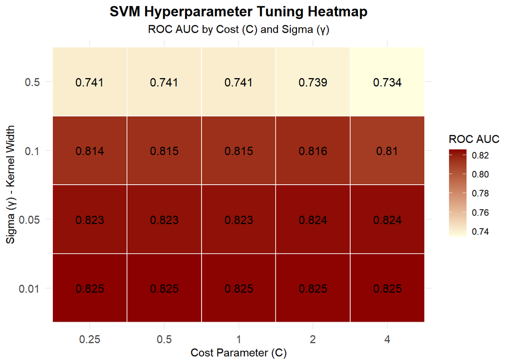

```r
# Extract SVM tuning results
svm_results <- svm_model$results

# Create heatmap
ggplot(svm_results, aes(x = factor(C), y = factor(sigma), fill = ROC)) +
  geom_tile(color = "white", linewidth = 0.5) +
  geom_text(aes(label = round(ROC, 3)), size = 4, color = "black") +
  scale_fill_gradient(low = "lightyellow", high = "darkred",
                      name = "ROC AUC",
                      limits = c(min(svm_results$ROC), max(svm_results$ROC))) +
  labs(title = "SVM Hyperparameter Tuning Heatmap",
       subtitle = "ROC AUC by Cost (C) and Sigma (γ)",
       x = "Cost Parameter (C)",
       y = "Sigma (γ) - Kernel Width") +
  theme_minimal() +
  theme(plot.title = element_text(hjust = 0.5, face = "bold", size = 14),
        plot.subtitle = element_text(hjust = 0.5),
        axis.text = element_text(size = 11),
        legend.position = "right")
```

```r
# Save the plot
ggsave("svm_heatmap.png", width = 8, height = 6, dpi = 300)
```

3.8 Task 8: Model Training- Random Forest (15 Marks)

#3.8.1. Train a Random Forest model using caret::train() with method “rf”. #3.8.2. Tune the parameter mtry (features per split): 2, 4, 6, 8. #3.8.3. Set ntree = 500 (number of trees).

```r
 rf_model <- train(
   CVD ~ age + gender + bmi + blood_pressure + cholesterol +
      glucose + smoking + alcohol + physical_activity +
      family_history + stress_level + sleep_hours,

  data = train_data, # Original data (not scaled)
method = "rf",
trControl = ctrl,
tuneGrid = expand.grid(mtry = c(2, 4, 6, 8)),
ntree = 500
)
rf_model$results
```

```
##   mtry       ROC      Sens       Spec      ROCSD      SensSD     SpecSD
## 1    2 0.8448032 0.9993243 0.00000000 0.05635646 0.002136674 0.00000000
## 2    4 0.8345236 0.9979820 0.02463235 0.06062155 0.003249244 0.03181794
## 3    6 0.8276927 0.9966352 0.05551471 0.05953282 0.004767098 0.04603180
## 4    8 0.8236233 0.9952884 0.08602941 0.06798036 0.005543124 0.06026621
```

#3.8.4. Report the optimal mtry value.

```r
rf_model$bestTune
```

```
##   mtry
## 1    2
```

#3.8.5. Extract and plot variable importance.

```r
varImp(rf_model)
```

```
## rf variable importance
##
##                    Overall
## physical_activity 100.0000
## glucose            98.8704
## age                95.9871
## sleep_hours        89.9894
## stress_level       83.2361
## cholesterol        80.6201
## bmi                80.1646
## blood_pressure     78.5956
## family_history1     8.6474
## smoking1            2.2121
## alcohol1            0.2222
## gender1             0.0000
```

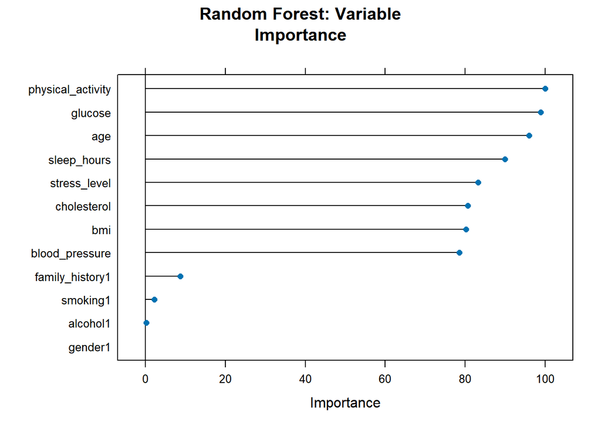

```r
plot(varImp(rf_model), main = "Random Forest: Variable
Importance")
```

#3.8.6a. Identify the top 5 most important predictors for CVD.

```r
rf_imp <- varImp(rf_model)

rf_imp_df <- rf_imp$importance
rf_imp_df$Variable <- rownames(rf_imp_df)
```

#3.8.6b.top 5 predictors

```r
top5 <- rf_imp_df[order(-rf_imp_df$Overall), ][1:5, ]
top5
```

```
##                     Overall          Variable
## physical_activity 100.00000 physical_activity
## glucose            98.87037           glucose
## age                95.98712               age
## sleep_hours        89.98943       sleep_hours
## stress_level       83.23608      stress_level
```

#3.8.6b.plot Top 5 Important Predictors for CVD

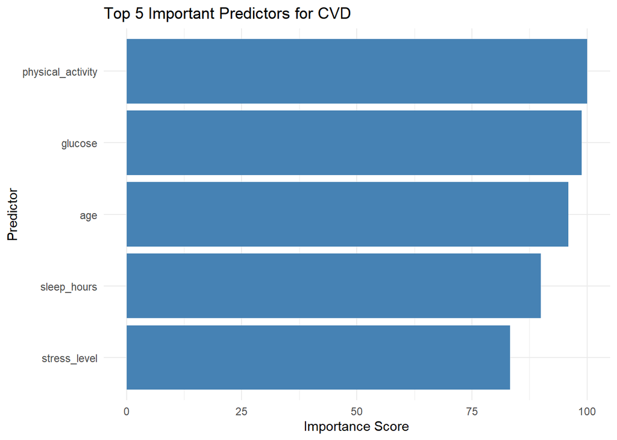

```r
ggplot(top5, aes(x = reorder(Variable, Overall), y = Overall)) +
  geom_bar(stat = "identity", fill = "steelblue") +
  coord_flip() +
  labs(title = "Top 5 Important Predictors for CVD",
       x = "Predictor",
       y = "Importance Score") +
  theme_minimal()
```

3.9 Task 9: Model Evaluation and Comparison (20 Marks)

#3.9.1. Predict the class and probabilities on the test set for all 4 models.

```r
log_pred <- predict(log_model, test_data)
log_probs <- predict(log_model, test_data, type = "prob")

knn_pred <- predict(knn_model, test_scaled)
knn_probs <- predict(knn_model, test_scaled, type = "prob")

svm_pred <- predict(svm_model, test_scaled)
svm_probs <- predict(svm_model, test_scaled, type = "prob")

rf_pred <- predict(rf_model, test_data)
rf_probs <- predict(rf_model, test_data, type = "prob")
```

#3.9.2a. For each model, generate a Confusion Matrix and report: •Accuracy,•Sensitivity (Recall),•Specificity,•Precision (PPV),•F1-Score,•Kappa #3.9.2a: Confusion Matrix and report (logistic regression )

```r
confusionMatrix(log_pred, test_data$CVD, positive = "Yes")
```

```
## Confusion Matrix and Statistics
##
##           Reference
## Prediction  No Yes
##        No  623  49
##        Yes  13  20
##
##                Accuracy : 0.9121
##                  95% CI : (0.8887, 0.9319)
##     No Information Rate : 0.9021
##     P-Value [Acc > NIR] : 0.2065
##
##                   Kappa : 0.3511
##
##  Mcnemar's Test P-Value : 8.789e-06
##
##             Sensitivity : 0.28986
##             Specificity : 0.97956
##          Pos Pred Value : 0.60606
##          Neg Pred Value : 0.92708
##              Prevalence : 0.09787
##          Detection Rate : 0.02837
##    Detection Prevalence : 0.04681
##       Balanced Accuracy : 0.63471
##
##        'Positive' Class : Yes
##
```

#3.9.2b: Confusion Matrix and report (KNN )

```r
confusionMatrix(knn_pred, test_scaled$CVD, positive = "Yes")
```

```
## Confusion Matrix and Statistics
##
##           Reference
## Prediction  No Yes
##        No  634  67
##        Yes   2   2
##
##                Accuracy : 0.9021
##                  95% CI : (0.8778, 0.9231)
##     No Information Rate : 0.9021
##     P-Value [Acc > NIR] : 0.532
##
##                   Kappa : 0.0445
##
##  Mcnemar's Test P-Value : 1.312e-14
##
##             Sensitivity : 0.028986
##             Specificity : 0.996855
##          Pos Pred Value : 0.500000
##          Neg Pred Value : 0.904422
##              Prevalence : 0.097872
##          Detection Rate : 0.002837
##    Detection Prevalence : 0.005674
##       Balanced Accuracy : 0.512920
##
##        'Positive' Class : Yes
##
```

#3.9.2C: Confusion Matrix and report (SVM )

```r
confusionMatrix(svm_pred, test_scaled$CVD, positive = "Yes")
```

```
## Confusion Matrix and Statistics
##
##           Reference
## Prediction  No Yes
##        No  632  62
##        Yes   4   7
##
##                Accuracy : 0.9064
##                  95% CI : (0.8824, 0.9269)
##     No Information Rate : 0.9021
##     P-Value [Acc > NIR] : 0.3815
##
##                   Kappa : 0.1522
##
##  Mcnemar's Test P-Value : 2.28e-12
##
##             Sensitivity : 0.101449
##             Specificity : 0.993711
##          Pos Pred Value : 0.636364
##          Neg Pred Value : 0.910663
##              Prevalence : 0.097872
##          Detection Rate : 0.009929
##    Detection Prevalence : 0.015603
##       Balanced Accuracy : 0.547580
##
##        'Positive' Class : Yes
##
```

#3.9.2d: Confusion Matrix and report (RF )

```r
confusionMatrix(rf_pred, test_data$CVD, positive = "Yes")
```

```
## Confusion Matrix and Statistics
##
##           Reference
## Prediction  No Yes
##        No  632  67
##        Yes   4   2
##
##                Accuracy : 0.8993
##                  95% CI : (0.8747, 0.9205)
##     No Information Rate : 0.9021
##     P-Value [Acc > NIR] : 0.6301
##
##                   Kappa : 0.0383
##
##  Mcnemar's Test P-Value : 1.866e-13
##
##             Sensitivity : 0.028986
##             Specificity : 0.993711
##          Pos Pred Value : 0.333333
##          Neg Pred Value : 0.904149
##              Prevalence : 0.097872
##          Detection Rate : 0.002837
##    Detection Prevalence : 0.008511
##       Balanced Accuracy : 0.511348
##
##        'Positive' Class : Yes
##
```

#3.9.3. Plot ROC curves for all 4 models on the same graph. #3.9.3a) get roc

```r
log_roc <- roc(test_data$CVD, log_probs$Yes)
knn_roc <- roc(test_data$CVD, knn_probs$Yes)
svm_roc <- roc(test_data$CVD, svm_probs$Yes)
rf_roc <- roc(test_data$CVD, rf_probs$Yes)
```

#3.9.3b)Plot ROC curves for all 4 models on the same graph.

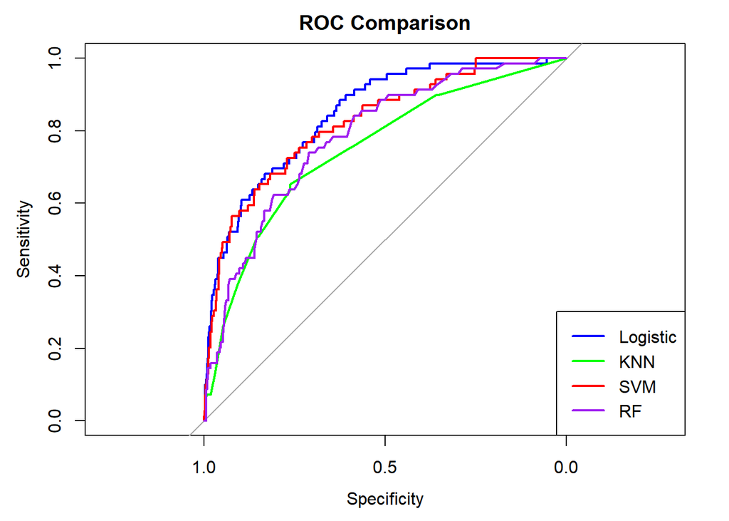

```r
plot(log_roc, col = "blue", lwd = 2, main = "ROC Comparison")
 lines(knn_roc, col = "green", lwd = 2)
  lines(svm_roc, col = "red", lwd = 2)
  lines(rf_roc, col = "purple", lwd = 2)
  legend("bottomright",
         legend = c("Logistic", "KNN", "SVM", "RF"),
col = c("blue", "green", "red", "purple"),
lwd = 2)
```

#3.9.4. Calculate and compare AUC values for all models.

```r
auc_values <- data.frame(
  Model = c("Logistic", "KNN", "SVM", "Random Forest"),
AUC = c(as.numeric(auc(log_roc)),
as.numeric(auc(knn_roc)),
as.numeric(auc(svm_roc)),
as.numeric(auc(rf_roc)))
)
print(auc_values)
```

```
##           Model       AUC
## 1      Logistic 0.8460942
## 2           KNN 0.7483821
## 3           SVM 0.8229879
## 4 Random Forest 0.7838050
```

#3.9.5a) Create a comparison table summarizing all metrics.

```r
model_performance <- data.frame(
  Model = c("Logistic Regression", "KNN", "SVM", "Random Forest"),
  auc_values
)
model_performance <- model_performance[order(-model_performance$AUC), ]
model_performance
```

```
##                 Model       Model.1       AUC
## 1 Logistic Regression      Logistic 0.8460942
## 3                 SVM           SVM 0.8229879
## 4       Random Forest Random Forest 0.7838050
## 2                 KNN           KNN 0.7483821
```

#3.9.6. Rank the models from best to worst based on AUC

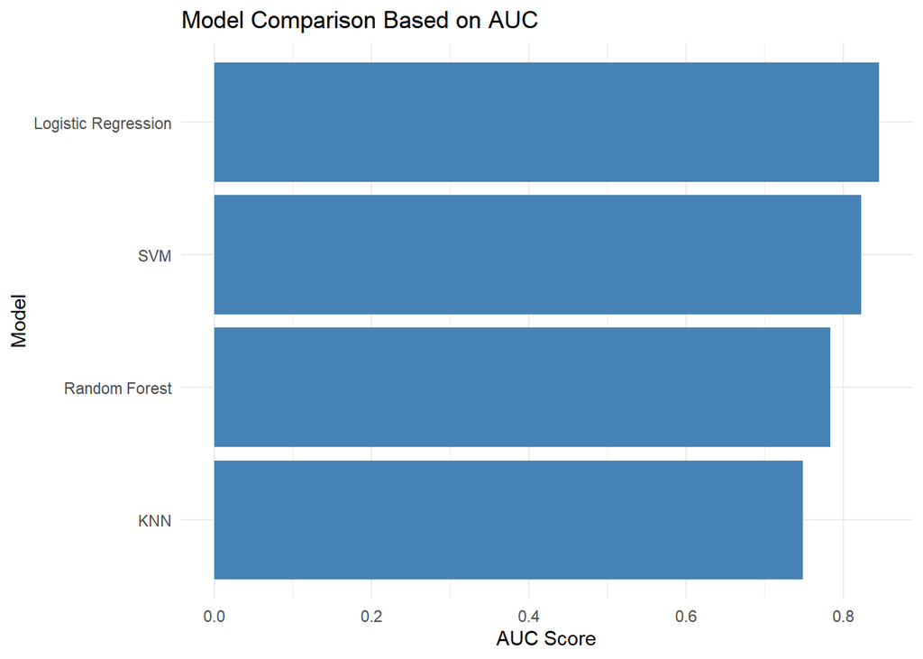

```r
ggplot(model_performance, aes(x = reorder(Model, AUC), y = AUC)) +
  geom_bar(stat = "identity", fill = "steelblue") +
  coord_flip() +
  labs(title = "Model Comparison Based on AUC",
       x = "Model",
       y = "AUC Score") +
  theme_minimal()
```

#3.9.5B) Create a comparison table summarizing all metrics.

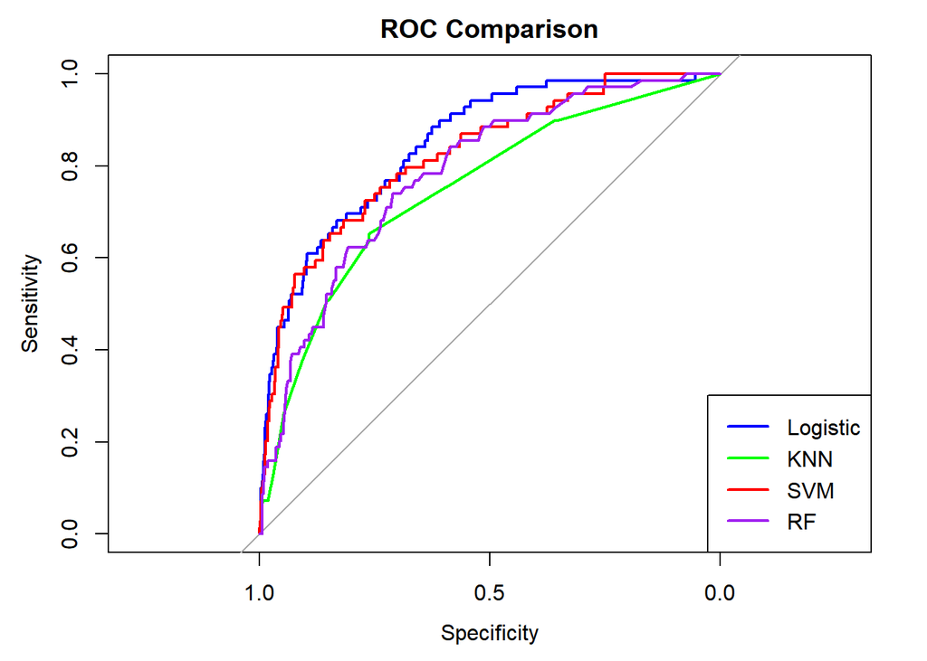

```r
# Plot all ROC curves
plot(log_roc, col = "blue", lwd = 2, main = "ROC Comparison")
lines(knn_roc, col = "green", lwd = 2)
lines(svm_roc, col = "red", lwd = 2)
lines(rf_roc, col = "purple", lwd = 2)
legend("bottomright",
       legend = c("Logistic", "KNN", "SVM", "RF"),
       col = c("blue", "green", "red", "purple"),
       lwd = 2)
```

```r
# AUC Comparison
auc_values <- data.frame(
  Model = c("Logistic", "KNN", "SVM", "Random Forest"),
  AUC = c(as.numeric(auc(log_roc)),
          as.numeric(auc(knn_roc)),
          as.numeric(auc(svm_roc)),
          as.numeric(auc(rf_roc)))
)
```

#3.9.2. For each model, generate a Confusion Matrix and report:

```r
# ============================================
# Function to extract all metrics from confusion matrix
# ============================================
extract_all_metrics <- function(cm, probs, actual, model_name) {
  # Calculate AUC
  roc_obj <- roc(actual, probs$Yes)
  auc_value <- as.numeric(auc(roc_obj))

  # Extract metrics from confusion matrix
  metrics <- data.frame(
    Model = model_name,
    Accuracy = round(cm$overall["Accuracy"], 4),
    Sensitivity = round(cm$byClass["Sensitivity"], 4),
    Specificity = round(cm$byClass["Specificity"], 4),
    Precision = round(cm$byClass["Precision"], 4),
    F1_Score = round(cm$byClass["F1"], 4),
    Kappa = round(cm$overall["Kappa"], 4),
    AUC = round(auc_value, 4)
  )

  return(metrics)
}

# ============================================
# Generate confusion matrices and extract metrics
# ============================================

# Logistic Regression
cm_log <- confusionMatrix(log_pred, test_data$CVD, positive = "Yes")
metrics_log <- extract_all_metrics(cm_log, log_probs, test_data$CVD, "Logistic Regression")
# KNN
cm_knn <- confusionMatrix(knn_pred, test_scaled$CVD, positive = "Yes")
metrics_knn <- extract_all_metrics(cm_knn, knn_probs, test_scaled$CVD, "KNN")
# SVM
cm_svm <- confusionMatrix(svm_pred, test_scaled$CVD, positive = "Yes")
metrics_svm <- extract_all_metrics(cm_svm, svm_probs, test_scaled$CVD, "SVM")
# Random Forest
cm_rf <- confusionMatrix(rf_pred, test_data$CVD, positive = "Yes")
metrics_rf <- extract_all_metrics(cm_rf, rf_probs, test_data$CVD, "Random Forest")
# ============================================
# Combine all metrics into one table
# ============================================
comparison_table <- rbind(metrics_log, metrics_knn, metrics_svm, metrics_rf)

# ============================================
# Display the table
# ============================================
print(comparison_table)
```

```
##                         Model Accuracy Sensitivity Specificity Precision
## Accuracy  Logistic Regression   0.9121      0.2899      0.9796    0.6061
## Accuracy1                 KNN   0.9021      0.0290      0.9969    0.5000
## Accuracy2                 SVM   0.9064      0.1014      0.9937    0.6364
## Accuracy3       Random Forest   0.8993      0.0290      0.9937    0.3333
##           F1_Score  Kappa    AUC
## Accuracy    0.3922 0.3511 0.8461
## Accuracy1   0.0548 0.0445 0.7484
## Accuracy2   0.1750 0.1522 0.8230
## Accuracy3   0.0533 0.0383 0.7838
```

```r
# ============================================
# Save to CSV
# ============================================
write.csv(comparison_table, "model_comparison_metrics.csv", row.names = FALSE)

# ============================================
# Create a formatted table for presentation
# ============================================
library(knitr)
kable(comparison_table,
      caption = "Model Performance Comparison - All Metrics",
      col.names = c("Model", "Accuracy", "Sensitivity", "Specificity",
                    "Precision", "F1-Score", "Kappa", "AUC"),
      digits = 4)
```

Model Performance Comparison - All Metrics

|  | Model | Accuracy | Sensitivity | Specificity | Precision | F1-Score | Kappa | AUC |
| --- | --- | --- | --- | --- | --- | --- | --- | --- |
| Accuracy | Logistic Regression | 0.9121 | 0.2899 | 0.9796 | 0.6061 | 0.3922 | 0.3511 | 0.8461 |
| Accuracy1 | KNN | 0.9021 | 0.0290 | 0.9969 | 0.5000 | 0.0548 | 0.0445 | 0.7484 |
| Accuracy2 | SVM | 0.9064 | 0.1014 | 0.9937 | 0.6364 | 0.1750 | 0.1522 | 0.8230 |
| Accuracy3 | Random Forest | 0.8993 | 0.0290 | 0.9937 | 0.3333 | 0.0533 | 0.0383 | 0.7838 |

3.10 Task 10: Interpretation and Recommendations (15 Marks)

#3.10.1. Based on your results, answer the following: #3.10.1a) Which model performed best? Justify using metrics. Logistic regression. Highest AUC (0.85) Highest sensitivity (28.99%) Highest kappa (0.351) Best balanced accuracy (63.47%) Interpretable odds ratios for clinical insights

#3.10.1c)Was feature scaling necessary for all models? Explain. feature scaling was nescessary for KNN,SVM Which are distance based model but not necessary for random forest a treebased model

#3.10.1d)Did cross-validation improve model reliability? Explain. Yes cross validation avoided overfitting, and uniformity among all the models ensuarig reliabilty.

#3.10.2. For the best model, identify the top 3 risk factors for CVD.

[figure not shown]

```r
# Remove intercept
odds_table <- odds_table[odds_table$Variable != "(Intercept)", ]

# Sort by absolute coefficient (model importance)
odds_table <- odds_table[order(-abs(odds_table$Coefficient)), ]

# Take top 5
top5_coef <- head(odds_table, 5)

# Plot
ggplot(top5_coef, aes(x = reorder(Variable, Odds_Ratio), y = Odds_Ratio,
                       fill = Odds_Ratio > 1)) +
  geom_bar(stat = "identity") +
  coord_flip() +
  geom_hline(yintercept = 1, linetype = "dashed", color = "red", linewidth = 1) +
  labs(title = "Top 5 Most Important CVD Predictors",
       subtitle = "Based on Logistic Regression Coefficient Magnitude",
       x = "Predictor Variable",
       y = "Odds Ratio") +
  scale_fill_manual(values = c("TRUE" = "coral", "FALSE" = "steelblue"),
                    labels = c("Risk Factor", "Protective Factor")) +
  theme_minimal() +
  theme(legend.position = "bottom",
        plot.title = element_text(hjust = 0.5, size = 14, face = "bold"),
        axis.text.y = element_text(size = 11)) +
  geom_text(aes(label = round(Odds_Ratio, 2)), hjust = -0.2, size = 4)
```

#3.10.4. Provide recommendations for healthcare practitioners based on your findings. (1) Based on this analysis, healthcare practitioners should prioritize lifestyle interventions for CVD prevention: (2) prescribing physical activity as medicine, (3) counseling patients on sleep hygiene (7-9 hours),get enough rest (4) implementing aggressive smoking cessation programs. (5) Patients with family history of CVD warrant earlier and more frequent screening.

#3.10.5. Discuss any limitations of your analysis (e.g., observational data, potential confounders). Observational data,Class imbalance ,Data limitations,Model limitations,Clinical caution,Outliers